# 데이터 소개

### visit occurrence

```python
vo = pd.read_csv('visit_occurrence.csv')
vo.head()
```

|  | visit_occurrence_id | person_id | visit_concept_id | visit_start_date | visit_start_datetime | visit_end_date | visit_end_datetime | visit_type_concept_id | provider_id | care_site_id | visit_source_value | visit_source_concept_id | admitting_source_concept_id | admitting_source_value | discharge_to_concept_id | discharge_to_source_value | preceding_visit_occurrence_id |
| --- | --- | --- | --- | --- | --- | --- | --- | --- | --- | --- | --- | --- | --- | --- | --- | --- | --- |
| 0 | 36112943 | 116496 | 9202 | 1962-04-13 | 1962-04-13 01:53:01 | 1962-04-13 | 1962-04-13 02:08:01 | 44818517 | NaN | NaN | ac25f574-971c-4685-8034-359a00b09857 | 0 | 0 | NaN | 0 | NaN | NaN |
| 1 | 36112944 | 116496 | 9202 | 1962-04-24 | 1962-04-24 01:53:01 | 1962-04-24 | 1962-04-24 02:08:01 | 44818517 | NaN | NaN | e7e02d9d-d16a-44cc-b3ce-42a5adb60095 | 0 | 0 | NaN | 0 | NaN | 36112943.0 |
| 2 | 36112954 | 116496 | 9202 | 2002-11-29 | 2002-11-29 01:53:01 | 2002-11-29 | 2002-11-29 02:23:01 | 44818517 | NaN | NaN | 2e49b738-ed61-4b93-bc31-4b305985709e | 0 | 0 | NaN | 0 | NaN | 36112944.0 |
| 3 | 36112945 | 116496 | 9202 | 2008-11-06 | 2008-11-06 01:53:01 | 2008-11-06 | 2008-11-06 02:08:01 | 44818517 | NaN | NaN | 2eccfac7-4443-4daa-901a-b4be10692426 | 0 | 0 | NaN | 0 | NaN | 36112954.0 |
| 4 | 36112946 | 116496 | 9202 | 2010-11-19 | 2010-11-19 01:53:01 | 2010-11-19 | 2010-11-19 02:43:01 | 44818517 | NaN | NaN | 71a06bd9-3d06-4635-88f4-4fe29305c83f | 0 | 0 | NaN | 0 | NaN | 36112945.0 |

```python
vo.info()
```

```
<class 'pandas.core.frame.DataFrame'>
RangeIndex: 41810 entries, 0 to 41809
Data columns (total 17 columns):
 #   Column                         Non-Null Count  Dtype
---  ------                         --------------  -----
 0   visit_occurrence_id            41810 non-null  int64
 1   person_id                      41810 non-null  int64
 2   visit_concept_id               41810 non-null  int64
 3   visit_start_date               41810 non-null  object
 4   visit_start_datetime           41810 non-null  object
 5   visit_end_date                 41810 non-null  object
 6   visit_end_datetime             41810 non-null  object
 7   visit_type_concept_id          41810 non-null  int64
 8   provider_id                    0 non-null      float64
 9   care_site_id                   0 non-null      float64
 10  visit_source_value             41810 non-null  object
 11  visit_source_concept_id        41810 non-null  int64
 12  admitting_source_concept_id    41810 non-null  int64
 13  admitting_source_value         0 non-null      float64
 14  discharge_to_concept_id        41810 non-null  int64
 15  discharge_to_source_value      0 non-null      float64
 16  preceding_visit_occurrence_id  40810 non-null  float64
dtypes: float64(5), int64(7), object(5)
memory usage: 5.4+ MB
```

```python
vo.drop(['provider_id', 'care_site_id', 'admitting_source_value', 'discharge_to_source_value'], axis=1, inplace=True)
```

```python
vo
```

|  | visit_occurrence_id | person_id | visit_concept_id | visit_start_date | visit_start_datetime | visit_end_date | visit_end_datetime | visit_type_concept_id | visit_source_value | visit_source_concept_id | admitting_source_concept_id | discharge_to_concept_id | preceding_visit_occurrence_id |
| --- | --- | --- | --- | --- | --- | --- | --- | --- | --- | --- | --- | --- | --- |
| 0 | 36112943 | 116496 | 9202 | 1962-04-13 | 1962-04-13 01:53:01 | 1962-04-13 | 1962-04-13 02:08:01 | 44818517 | ac25f574-971c-4685-8034-359a00b09857 | 0 | 0 | 0 | NaN |
| 1 | 36112944 | 116496 | 9202 | 1962-04-24 | 1962-04-24 01:53:01 | 1962-04-24 | 1962-04-24 02:08:01 | 44818517 | e7e02d9d-d16a-44cc-b3ce-42a5adb60095 | 0 | 0 | 0 | 36112943.0 |
| 2 | 36112954 | 116496 | 9202 | 2002-11-29 | 2002-11-29 01:53:01 | 2002-11-29 | 2002-11-29 02:23:01 | 44818517 | 2e49b738-ed61-4b93-bc31-4b305985709e | 0 | 0 | 0 | 36112944.0 |
| 3 | 36112945 | 116496 | 9202 | 2008-11-06 | 2008-11-06 01:53:01 | 2008-11-06 | 2008-11-06 02:08:01 | 44818517 | 2eccfac7-4443-4daa-901a-b4be10692426 | 0 | 0 | 0 | 36112954.0 |
| 4 | 36112946 | 116496 | 9202 | 2010-11-19 | 2010-11-19 01:53:01 | 2010-11-19 | 2010-11-19 02:43:01 | 44818517 | 71a06bd9-3d06-4635-88f4-4fe29305c83f | 0 | 0 | 0 | 36112945.0 |
| ... | ... | ... | ... | ... | ... | ... | ... | ... | ... | ... | ... | ... | ... |
| 41805 | 48895529 | 2781995 | 9202 | 2018-02-14 | 2018-02-14 15:20:07 | 2018-02-14 | 2018-02-14 15:50:07 | 44818517 | 09fdf1f4-7f4c-495c-a3f5-0a23dc1f42d3 | 0 | 0 | 0 | 48895528.0 |
| 41806 | 48895530 | 2781995 | 9202 | 2019-02-20 | 2019-02-20 15:20:07 | 2019-02-20 | 2019-02-20 15:50:07 | 44818517 | 0669ae2b-63bb-4723-bb3b-34141071c329 | 0 | 0 | 0 | 48895529.0 |
| 41807 | 48895520 | 2781995 | 9202 | 2019-08-30 | 2019-08-30 15:20:07 | 2019-08-30 | 2019-08-30 15:35:07 | 44818517 | 6486d5f5-44b2-492e-b7f6-d65b60ac5fca | 0 | 0 | 0 | 48895530.0 |
| 41808 | 48895531 | 2781995 | 9202 | 2020-02-26 | 2020-02-26 15:20:07 | 2020-02-26 | 2020-02-26 15:35:07 | 44818517 | 81174d5c-caa5-4eda-aa11-5f13a59dfdfc | 0 | 0 | 0 | 48895520.0 |
| 41809 | 48895521 | 2781995 | 9202 | 2020-03-08 | 2020-03-08 15:20:07 | 2020-03-08 | 2020-03-08 16:07:07 | 44818517 | 1a223912-64a8-43c2-a8d7-7c46a02b897b | 0 | 0 | 0 | 48895531.0 |

41810 rows × 13 columns

```python
# 결측값으로 구성된 항목 및 중복/무의미 항목 제거

print(vo.visit_occurrence_id.nunique())
print(vo.person_id.nunique())
print(vo.visit_concept_id.nunique())
print(vo.visit_type_concept_id.nunique())
print(vo.visit_source_value.nunique())
print(vo.visit_source_concept_id.nunique())
print(vo.admitting_source_concept_id.nunique())
print(vo.discharge_to_concept_id.nunique())
print(vo.preceding_visit_occurrence_id.nunique())
```

```
41810
1000
3
1
41810
1
1
1
40810
```

```python
vo.drop(['visit_start_datetime', 'visit_end_datetime', 'visit_type_concept_id', 'visit_source_value', 'visit_source_concept_id', 'admitting_source_concept_id', 'discharge_to_concept_id'], axis=1, inplace=True)
```

```python
vo
```

|  | visit_occurrence_id | person_id | visit_concept_id | visit_start_date | visit_end_date | preceding_visit_occurrence_id |
| --- | --- | --- | --- | --- | --- | --- |
| 0 | 36112943 | 116496 | 9202 | 1962-04-13 | 1962-04-13 | NaN |
| 1 | 36112944 | 116496 | 9202 | 1962-04-24 | 1962-04-24 | 36112943.0 |
| 2 | 36112954 | 116496 | 9202 | 2002-11-29 | 2002-11-29 | 36112944.0 |
| 3 | 36112945 | 116496 | 9202 | 2008-11-06 | 2008-11-06 | 36112954.0 |
| 4 | 36112946 | 116496 | 9202 | 2010-11-19 | 2010-11-19 | 36112945.0 |
| ... | ... | ... | ... | ... | ... | ... |
| 41805 | 48895529 | 2781995 | 9202 | 2018-02-14 | 2018-02-14 | 48895528.0 |
| 41806 | 48895530 | 2781995 | 9202 | 2019-02-20 | 2019-02-20 | 48895529.0 |
| 41807 | 48895520 | 2781995 | 9202 | 2019-08-30 | 2019-08-30 | 48895530.0 |
| 41808 | 48895531 | 2781995 | 9202 | 2020-02-26 | 2020-02-26 | 48895520.0 |
| 41809 | 48895521 | 2781995 | 9202 | 2020-03-08 | 2020-03-08 | 48895531.0 |

41810 rows × 6 columns

### death

```python
death.head()
```

|  | person_id | death_date | death_datetime | death_type_concept_id | cause_concept_id | cause_source_value | cause_source_concept_id |
| --- | --- | --- | --- | --- | --- | --- | --- |
| 0 | 1691806 | 2015-06-02 | NaN | 32815 | 0 | 233604007 | 0 |
| 1 | 99181 | 2018-11-04 | NaN | 32815 | 0 | 87433001 | 0 |
| 2 | 2738610 | 1998-03-28 | NaN | 32815 | 0 | 262574004 | 0 |
| 3 | 31196 | 2020-03-16 | NaN | 32815 | 0 | 840539006 | 0 |
| 4 | 994339 | 2006-03-08 | NaN | 32815 | 0 | 22298006 | 0 |

```python
death.info()
```

```
<class 'pandas.core.frame.DataFrame'>
RangeIndex: 152 entries, 0 to 151
Data columns (total 7 columns):
 #   Column                   Non-Null Count  Dtype
---  ------                   --------------  -----
 0   person_id                152 non-null    int64
 1   death_date               152 non-null    object
 2   death_datetime           0 non-null      float64
 3   death_type_concept_id    152 non-null    int64
 4   cause_concept_id         152 non-null    int64
 5   cause_source_value       152 non-null    int64
 6   cause_source_concept_id  152 non-null    int64
dtypes: float64(1), int64(5), object(1)
memory usage: 8.4+ KB
```

```python
# 결측값으로 구성된 항목 및 중복/무의미 항목 제거

print(death.death_datetime.nunique())
print(death.cause_concept_id.nunique())
print(death.death_type_concept_id.nunique())
print(death.cause_source_value.nunique())
print(death.cause_source_concept_id.nunique())
```

```
0
1
1
20
1
```

```python
death.drop(['death_datetime', 'death_type_concept_id', 'cause_concept_id', 'cause_source_concept_id'], axis=1, inplace=True)
```

```python
death
```

|  | person_id | death_date | cause_source_value |
| --- | --- | --- | --- |
| 0 | 1691806 | 2015-06-02 | 233604007 |
| 1 | 99181 | 2018-11-04 | 87433001 |
| 2 | 2738610 | 1998-03-28 | 262574004 |
| 3 | 31196 | 2020-03-16 | 840539006 |
| 4 | 994339 | 2006-03-08 | 22298006 |
| ... | ... | ... | ... |
| 147 | 359466 | 1937-10-22 | 95281009 |
| 148 | 1891866 | 1998-10-11 | 126906006 |
| 149 | 533445 | 2003-08-06 | 22298006 |
| 150 | 2399178 | 2020-02-05 | 22298006 |
| 151 | 631283 | 2017-11-16 | 230690007 |

152 rows × 3 columns

# 분석 방향

- 비록 가상의 데이터이지만 인종 분포는 미국을 연상케 한다. 그래서 미국 의료 데이터를 EDA한다고 가정해보겠다.병원 방문 목적은 크게 예방과 의료로 나눠서 볼 수 있겠다.미국의 의료 서비스는 비용적 부담이 상당한 것으로 알려져 있다.그러니 증상이 심하지 않은 경우 방문이 꺼려지게 될 수 있다.다시 말해, 예방 목적으로 방문하는 경우는 드물것으로 예상되며, 치료 목적으로 방문하는 경우가 더 일반적일 것으로 보인다.
- 대부분의 상병은 나이와 건강상태가 통상적으로 음의 상관관계를 보이며 인종과 성별에 따라서 신체적 조건 뿐만 아니라, 행동 및 사회적 요인을 더불어 병적증세를 대하는 태도도 다를 수 있을 것으로 예상된다. 상병에 따라서 증상이 다를 수 있는 점까지 감안해서 환자의 특징과 관리수준이 사망률과 어느 정도의 연관성이 있는지 탐색적 분석을 진행하겠다.
- 환자 특징
  - 성별
  - 나이
  - 진단 병명
- 환자 관리수준
  - 입원 외래 응급: 적극적인 관리로 예방 혹은 치료
  - 내원일수
  - 의약품

# 데이터 결합

## 프로필: 수진자별 기록

### profile: person + death

```python
person.head()
```

|  | person_id | birth_datetime | race_source_value | ethnicity_source_value | male |
| --- | --- | --- | --- | --- | --- |
| 0 | 402435 | 1997-04-18 00:00:00 | white | hispanic | 0 |
| 1 | 1022983 | 1950-02-26 00:00:00 | white | hispanic | 1 |
| 2 | 1657794 | 1937-12-10 00:00:00 | white | hispanic | 0 |
| 3 | 2845932 | 1987-05-26 00:00:00 | asian | hispanic | 1 |
| 4 | 2693038 | 1959-02-07 00:00:00 | white | nonhispanic | 0 |

```python
death.head()
```

|  | person_id | death_date | cause_source_value |
| --- | --- | --- | --- |
| 0 | 1691806 | 2015-06-02 | 233604007 |
| 1 | 99181 | 2018-11-04 | 87433001 |
| 2 | 2738610 | 1998-03-28 | 262574004 |
| 3 | 31196 | 2020-03-16 | 840539006 |
| 4 | 994339 | 2006-03-08 | 22298006 |

```python
profile = pd.merge(person, death, how='outer')
profile.head()
```

|  | person_id | birth_datetime | race_source_value | ethnicity_source_value | male | death_date | cause_source_value |
| --- | --- | --- | --- | --- | --- | --- | --- |
| 0 | 402435 | 1997-04-18 00:00:00 | white | hispanic | 0 | NaN | NaN |
| 1 | 1022983 | 1950-02-26 00:00:00 | white | hispanic | 1 | NaN | NaN |
| 2 | 1657794 | 1937-12-10 00:00:00 | white | hispanic | 0 | NaN | NaN |
| 3 | 2845932 | 1987-05-26 00:00:00 | asian | hispanic | 1 | NaN | NaN |
| 4 | 2693038 | 1959-02-07 00:00:00 | white | nonhispanic | 0 | NaN | NaN |

```python
# 사망자 one-hot encoding

profile['death'] = 1
profile['death'][profile.death_date.isnull()] = 0
```

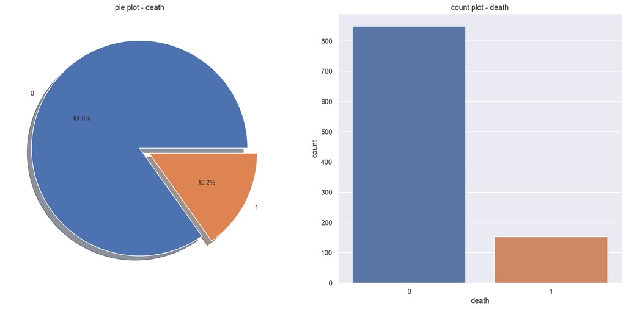

```python
# 1000명의 샘플 데이터 중 사망자가 차지하는 비율 15.2%

%matplotlib inline
f, ax = plt.subplots(1,2, figsize=(18,8))

profile['death'].value_counts().plot.pie(explode=[0,0.1], autopct='%1.1f%%', ax=ax[0], shadow=True)
ax[0].set_title('pie plot - death')
ax[0].set_ylabel('')

sns.countplot('death', data=profile, ax=ax[1])
ax[1].set_title('count plot - death')

plt.show()
```

### survived: profile 중 생존환자

```python
survived = profile[profile.death == 0]
```

```python
# str에서 datetime으로 변환

survived['birth_datetime'] = survived.birth_datetime.apply(lambda x: datetime.datetime.strptime(x, '%Y-%m-%d %H:%M:%S'))
survived['birth_datetime'] = survived.birth_datetime.apply(lambda x: x.date())
```

```python
# 마지막 사망 환자 기록은 20년 4월
np.max(death_profile.death_date)
```

```
Timestamp('2020-04-08 00:00:00')
```

```python
# 죽지 않았으면 2021년 2월 7일까지 생존했다 가정해도 무방할듯하다
def calculate_age(birthdate):
    return datetime.datetime.today().year - birthdate.year - ((datetime.datetime.today().month, datetime.datetime.today().day) < (birthdate.month, birthdate.day))
```

```python
survived['age'] = survived.apply(lambda x: calculate_age(x.birth_datetime), axis=1)
```

```python
survived
```

|  | person_id | birth_datetime | race_source_value | ethnicity_source_value | male | death_date | cause_source_value | death | age |
| --- | --- | --- | --- | --- | --- | --- | --- | --- | --- |
| 0 | 402435 | 1997-04-18 | white | hispanic | 0 | NaN | NaN | 0 | 23 |
| 1 | 1022983 | 1950-02-26 | white | hispanic | 1 | NaN | NaN | 0 | 70 |
| 2 | 1657794 | 1937-12-10 | white | hispanic | 0 | NaN | NaN | 0 | 83 |
| 3 | 2845932 | 1987-05-26 | asian | hispanic | 1 | NaN | NaN | 0 | 33 |
| 4 | 2693038 | 1959-02-07 | white | nonhispanic | 0 | NaN | NaN | 0 | 62 |
| ... | ... | ... | ... | ... | ... | ... | ... | ... | ... |
| 995 | 680801 | 2006-11-02 | white | nonhispanic | 0 | NaN | NaN | 0 | 14 |
| 996 | 1258670 | 1970-12-27 | white | hispanic | 0 | NaN | NaN | 0 | 50 |
| 997 | 1209983 | 1998-07-10 | white | nonhispanic | 0 | NaN | NaN | 0 | 22 |
| 998 | 2565313 | 1965-05-14 | white | nonhispanic | 0 | NaN | NaN | 0 | 55 |
| 999 | 277792 | 1954-04-17 | white | nonhispanic | 1 | NaN | NaN | 0 | 66 |

848 rows × 9 columns

### death_profile: profile 중 사망자

```python
death_profile = profile[profile.death == 1]
```

```python
death_profile
```

|  | person_id | birth_datetime | race_source_value | ethnicity_source_value | male | death_date | cause_source_value | death |
| --- | --- | --- | --- | --- | --- | --- | --- | --- |
| 5 | 397137 | 1924-04-10 00:00:00 | white | nonhispanic | 1 | 2011-08-11 | 410429000.0 | 1 |
| 9 | 508550 | 1917-07-25 00:00:00 | white | nonhispanic | 0 | 1918-10-02 | 95281009.0 | 1 |
| 10 | 133626 | 1961-07-15 00:00:00 | white | nonhispanic | 0 | 2012-05-26 | 233604007.0 | 1 |
| 11 | 2460892 | 1960-05-11 00:00:00 | white | nonhispanic | 0 | 2019-07-08 | 254637007.0 | 1 |
| 16 | 1742971 | 1947-02-11 00:00:00 | white | nonhispanic | 0 | 1996-04-09 | 87433001.0 | 1 |
| ... | ... | ... | ... | ... | ... | ... | ... | ... |
| 961 | 275512 | 1921-06-25 00:00:00 | white | nonhispanic | 1 | 1986-09-02 | 126906006.0 | 1 |
| 971 | 1743075 | 1937-12-05 00:00:00 | white | nonhispanic | 1 | 2020-03-04 | 840539006.0 | 1 |
| 973 | 81025 | 1930-01-29 00:00:00 | white | nonhispanic | 1 | 2020-03-26 | 840539006.0 | 1 |
| 981 | 1635233 | 1981-05-13 00:00:00 | white | nonhispanic | 1 | 2013-08-03 | 95281009.0 | 1 |
| 982 | 1059760 | 1947-07-07 00:00:00 | white | nonhispanic | 0 | 2020-03-20 | 840539006.0 | 1 |

152 rows × 8 columns

```python
def calculate_age(birthdate, deathdate):
    return int(deathdate.year - birthdate.year) - ((deathdate.month, deathdate.day) < (birthdate.month, birthdate.day))
```

```python
death_profile['birth_datetime'] = death_profile.birth_datetime.apply(lambda x: datetime.datetime.strptime(x, '%Y-%m-%d %H:%M:%S'))
death_profile['birth_datetime'] = death_profile.birth_datetime.apply(lambda x: x.date())
```

```python
death_profile['death_date'] = death_profile.death_date.apply(lambda x: datetime.datetime.strptime(x, '%Y-%m-%d'))
```

```python
death_profile
```

|  | person_id | birth_datetime | race_source_value | ethnicity_source_value | male | death_date | cause_source_value | death |
| --- | --- | --- | --- | --- | --- | --- | --- | --- |
| 5 | 397137 | 1924-04-10 | white | nonhispanic | 1 | 2011-08-11 | 410429000.0 | 1 |
| 9 | 508550 | 1917-07-25 | white | nonhispanic | 0 | 1918-10-02 | 95281009.0 | 1 |
| 10 | 133626 | 1961-07-15 | white | nonhispanic | 0 | 2012-05-26 | 233604007.0 | 1 |
| 11 | 2460892 | 1960-05-11 | white | nonhispanic | 0 | 2019-07-08 | 254637007.0 | 1 |
| 16 | 1742971 | 1947-02-11 | white | nonhispanic | 0 | 1996-04-09 | 87433001.0 | 1 |
| ... | ... | ... | ... | ... | ... | ... | ... | ... |
| 961 | 275512 | 1921-06-25 | white | nonhispanic | 1 | 1986-09-02 | 126906006.0 | 1 |
| 971 | 1743075 | 1937-12-05 | white | nonhispanic | 1 | 2020-03-04 | 840539006.0 | 1 |
| 973 | 81025 | 1930-01-29 | white | nonhispanic | 1 | 2020-03-26 | 840539006.0 | 1 |
| 981 | 1635233 | 1981-05-13 | white | nonhispanic | 1 | 2013-08-03 | 95281009.0 | 1 |
| 982 | 1059760 | 1947-07-07 | white | nonhispanic | 0 | 2020-03-20 | 840539006.0 | 1 |

152 rows × 8 columns

```python
# 사망일자 - 생일로 나이변수 파생
death_profile['age'] = death_profile.apply(lambda x: calculate_age(x.birth_datetime, x.death_date), axis=1)
```

```python
death_profile
```

|  | person_id | birth_datetime | race_source_value | ethnicity_source_value | male | death_date | cause_source_value | death | age |
| --- | --- | --- | --- | --- | --- | --- | --- | --- | --- |
| 5 | 397137 | 1924-04-10 | white | nonhispanic | 1 | 2011-08-11 | 410429000.0 | 1 | 87 |
| 9 | 508550 | 1917-07-25 | white | nonhispanic | 0 | 1918-10-02 | 95281009.0 | 1 | 1 |
| 10 | 133626 | 1961-07-15 | white | nonhispanic | 0 | 2012-05-26 | 233604007.0 | 1 | 50 |
| 11 | 2460892 | 1960-05-11 | white | nonhispanic | 0 | 2019-07-08 | 254637007.0 | 1 | 59 |
| 16 | 1742971 | 1947-02-11 | white | nonhispanic | 0 | 1996-04-09 | 87433001.0 | 1 | 49 |
| ... | ... | ... | ... | ... | ... | ... | ... | ... | ... |
| 961 | 275512 | 1921-06-25 | white | nonhispanic | 1 | 1986-09-02 | 126906006.0 | 1 | 65 |
| 971 | 1743075 | 1937-12-05 | white | nonhispanic | 1 | 2020-03-04 | 840539006.0 | 1 | 82 |
| 973 | 81025 | 1930-01-29 | white | nonhispanic | 1 | 2020-03-26 | 840539006.0 | 1 | 90 |
| 981 | 1635233 | 1981-05-13 | white | nonhispanic | 1 | 2013-08-03 | 95281009.0 | 1 | 32 |
| 982 | 1059760 | 1947-07-07 | white | nonhispanic | 0 | 2020-03-20 | 840539006.0 | 1 | 72 |

152 rows × 9 columns

#### 성별에 따른 death count

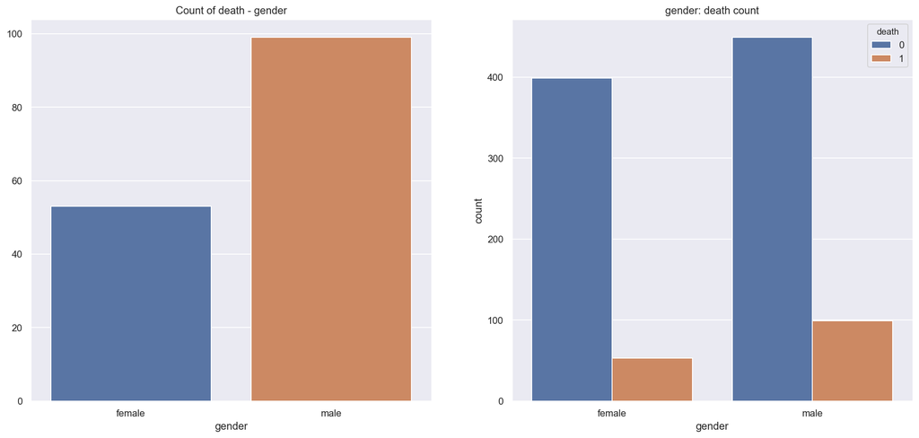

```python
# 남성의 death기록이 더 많다

f, ax = plt.subplots(1,2,figsize=(18,8))

sns.countplot('male', data=death_profile, ax=ax[0])
ax[0].set_title('Count of death - gender')
ax[0].set_xlabel('gender')
ax[0].set_xticklabels(['female', 'male'])
ax[0].set_ylabel('')

sns.countplot('male', hue='death', data=profile, ax=ax[1])
ax[1].set_title('gender: death count')
ax[1].set_xlabel('gender')
ax[1].set_xticklabels(['female', 'male'])

plt.show()
```

## 인종

```python
# race one-hot encoding
race_profile = pd.concat([profile, pd.get_dummies(profile.race_source_value)], axis=1)
```

```python
race_profile.head()
```

|  | person_id | birth_datetime | race_source_value | ethnicity_source_value | male | death_date | cause_source_value | death | asian | black | native | other | white |
| --- | --- | --- | --- | --- | --- | --- | --- | --- | --- | --- | --- | --- | --- |
| 0 | 402435 | 1997-04-18 00:00:00 | white | hispanic | 0 | NaN | NaN | 0 | 0 | 0 | 0 | 0 | 1 |
| 1 | 1022983 | 1950-02-26 00:00:00 | white | hispanic | 1 | NaN | NaN | 0 | 0 | 0 | 0 | 0 | 1 |
| 2 | 1657794 | 1937-12-10 00:00:00 | white | hispanic | 0 | NaN | NaN | 0 | 0 | 0 | 0 | 0 | 1 |
| 3 | 2845932 | 1987-05-26 00:00:00 | asian | hispanic | 1 | NaN | NaN | 0 | 1 | 0 | 0 | 0 | 0 |
| 4 | 2693038 | 1959-02-07 00:00:00 | white | nonhispanic | 0 | NaN | NaN | 0 | 0 | 0 | 0 | 0 | 1 |

```python
# 백인이 샘플 인구 중 약 85% 차지
# 남녀 성비는 거의 반반으로 이루어져 있다

race_profile.describe()
```

|  | person_id | male | cause_source_value | death | asian | black | native | other | white |
| --- | --- | --- | --- | --- | --- | --- | --- | --- | --- |
| count | 1.000000e+03 | 1000.00000 | 1.520000e+02 | 1000.000000 | 1000.000000 | 1000.000000 | 1000.000000 | 1000.000000 | 1000.000000 |
| mean | 1.455435e+06 | 0.54800 | 2.694972e+08 | 0.152000 | 0.065000 | 0.086000 | 0.003000 | 0.001000 | 0.845000 |
| std | 8.225775e+05 | 0.49794 | 2.784464e+08 | 0.359201 | 0.246649 | 0.280504 | 0.054717 | 0.031623 | 0.362086 |
| min | 2.955000e+03 | 0.00000 | 2.229801e+07 | 0.000000 | 0.000000 | 0.000000 | 0.000000 | 0.000000 | 0.000000 |
| 25% | 7.343485e+05 | 0.00000 | 9.255325e+07 | 0.000000 | 0.000000 | 0.000000 | 0.000000 | 0.000000 | 1.000000 |
| 50% | 1.455498e+06 | 1.00000 | 2.076755e+08 | 0.000000 | 0.000000 | 0.000000 | 0.000000 | 0.000000 | 1.000000 |
| 75% | 2.179356e+06 | 1.00000 | 2.625740e+08 | 0.000000 | 0.000000 | 0.000000 | 0.000000 | 0.000000 | 1.000000 |
| max | 2.845932e+06 | 1.00000 | 8.405390e+08 | 1.000000 | 1.000000 | 1.000000 | 1.000000 | 1.000000 | 1.000000 |

### 인종과 연령

#### 모든 환자 인종별 분포

```python
# 순서가 살짝 바뀜
survived.drop('death_date', axis=1, inplace=True)
```

```python
profile2 = pd.merge(survived, death_profile, how='outer')
```

```python
pd.crosstab(profile['race_source_value'], profile['ethnicity_source_value'], margins=True)
```

| ethnicity_source_value race_source_value | hispanic | nonhispanic | All |
| --- | --- | --- | --- |
| asian | 8 | 57 | 65 |
| black | 10 | 76 | 86 |
| native | 1 | 2 | 3 |
| other | 0 | 1 | 1 |
| white | 101 | 744 | 845 |
| All | 120 | 880 | 1000 |

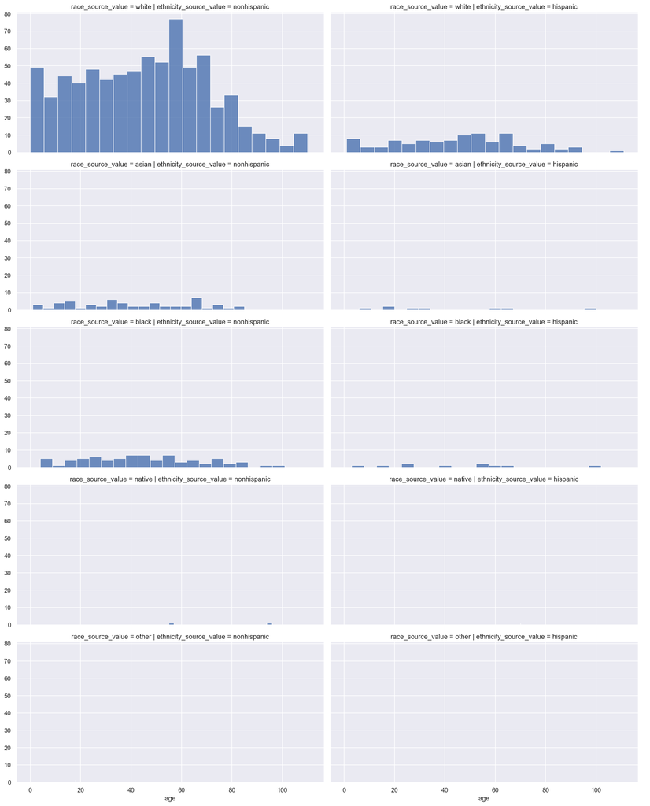

```python
grid = sns.FacetGrid(profile2, row='race_source_value', col='ethnicity_source_value', height=4, aspect=2, col_order=['nonhispanic', 'hispanic'])
grid.map(plt.hist, 'age', alpha=.8, bins=20)
grid.add_legend();
```

#### 생존 환자 인종별 분포

```python
pd.crosstab(survived['race_source_value'], survived['ethnicity_source_value'], margins=True)
```

| ethnicity_source_value race_source_value | hispanic | nonhispanic | All |
| --- | --- | --- | --- |
| asian | 8 | 47 | 55 |
| black | 8 | 64 | 72 |
| native | 1 | 2 | 3 |
| other | 0 | 1 | 1 |
| white | 84 | 633 | 717 |
| All | 101 | 747 | 848 |

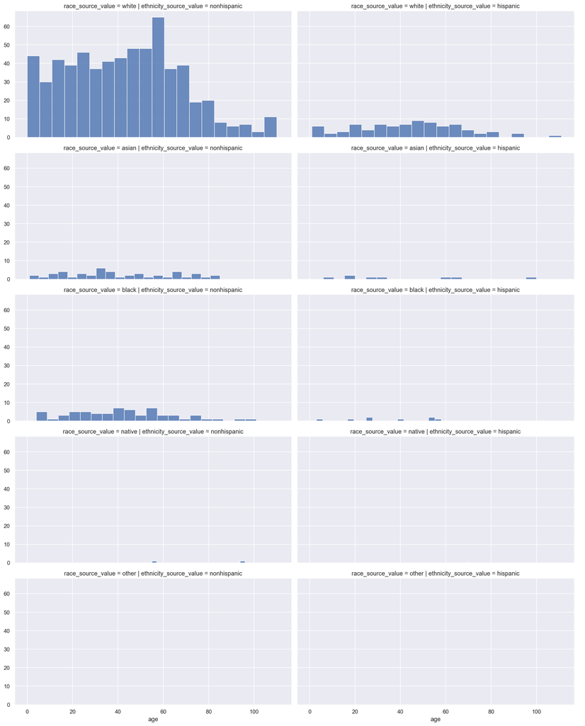

```python
# 백인 생존 환자만 두고 봤을때 분포가 왜도가 양수일거 같은 정규분포의 형태를 이룬다
grid = sns.FacetGrid(survived, row='race_source_value', col='ethnicity_source_value', height=4, aspect=2, col_order=['nonhispanic', 'hispanic'])
grid.map(plt.hist, 'age', alpha=.8, bins=20)
grid.add_legend();
```

#### 사망 환자 인종별 분포

```python
# others, native는 사망자가 없음
pd.crosstab(death_profile['race_source_value'], death_profile['ethnicity_source_value'], margins=True)
```

| ethnicity_source_value race_source_value | hispanic | nonhispanic | All |
| --- | --- | --- | --- |
| asian | 0 | 10 | 10 |
| black | 2 | 12 | 14 |
| white | 17 | 111 | 128 |
| All | 19 | 133 | 152 |

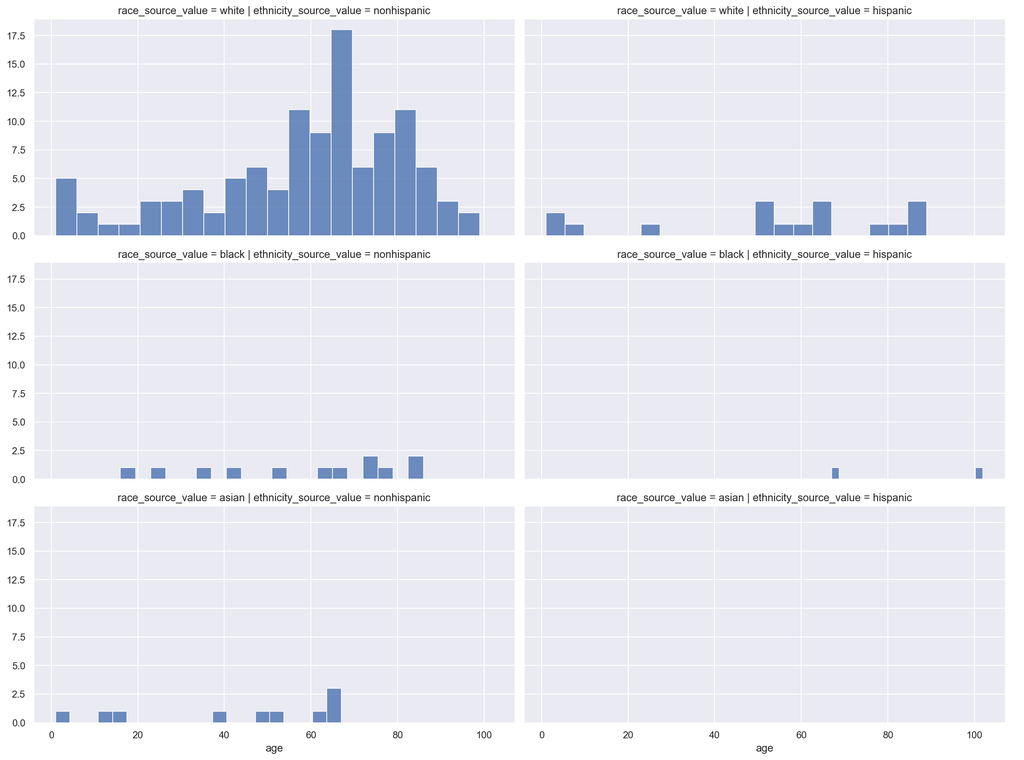

```python
# white nonhispanic의 경우 survived와 반대로 꼬리가 왼쪽에 있다

grid = sns.FacetGrid(death_profile, row='race_source_value', col='ethnicity_source_value', height=4, aspect=2)
grid.map(plt.hist, 'age', alpha=.8, bins=20)
grid.add_legend();
```

```python
# 사망과 인종의 유의한 수준을 보기에는 데이터의 크기가 작지만 카테고리별로도 골고루 분포되어 있지 않아서 분석하는데는 한계가 있다고 본다
# 분석은 백인을 중점으로 진행한다
```

```python
cvo.info()
```

```
<class 'pandas.core.frame.DataFrame'>
Int64Index: 12167 entries, 0 to 12166
Data columns (total 11 columns):
 #   Column                         Non-Null Count  Dtype
---  ------                         --------------  -----
 0   person_id                      12167 non-null  int64
 1   condition_occurrence_id        12167 non-null  int64
 2   condition_concept_id           12167 non-null  int64
 3   condition_start_date           12167 non-null  object
 4   condition_end_date             8258 non-null   object
 5   visit_occurrence_id            12167 non-null  int64
 6   condition_source_value         12167 non-null  int64
 7   visit_concept_id               12167 non-null  int64
 8   visit_start_date               12167 non-null  object
 9   visit_end_date                 12167 non-null  object
 10  preceding_visit_occurrence_id  11513 non-null  float64
dtypes: float64(1), int64(6), object(4)
memory usage: 1.1+ MB
```

```python
cvo.head()
```

|  | person_id | condition_occurrence_id | condition_concept_id | condition_start_date | condition_end_date | visit_occurrence_id | condition_source_value | visit_concept_id | visit_start_date | visit_end_date | preceding_visit_occurrence_id |
| --- | --- | --- | --- | --- | --- | --- | --- | --- | --- | --- | --- |
| 0 | 116496 | 1466183 | 0 | 2002-11-29 | NaN | 36112954 | 162864005 | 9202 | 2002-11-29 | 2002-11-29 | 36112944.0 |
| 1 | 116496 | 1466184 | 0 | 2020-03-04 | 2020-03-04 | 36112952 | 840544004 | 9202 | 2020-03-04 | 2020-03-04 | 36112964.0 |
| 2 | 116496 | 1466187 | 312437 | 2020-03-04 | 2020-04-04 | 36112952 | 267036007 | 9202 | 2020-03-04 | 2020-03-04 | 36112964.0 |
| 3 | 116496 | 1466188 | 314754 | 2020-03-04 | 2020-04-04 | 36112952 | 56018004 | 9202 | 2020-03-04 | 2020-03-04 | 36112964.0 |
| 4 | 116496 | 1466190 | 4223659 | 2020-03-04 | 2020-04-04 | 36112952 | 84229001 | 9202 | 2020-03-04 | 2020-03-04 | 36112964.0 |

```python
white_profile
```

|  | person_id | birth_datetime | race_source_value | ethnicity_source_value | male | cause_source_value | death | age | death_date | hispanic | nonhispanic |
| --- | --- | --- | --- | --- | --- | --- | --- | --- | --- | --- | --- |
| 0 | 402435 | 1997-04-18 | white | hispanic | 0 | NaN | 0 | 23 | NaT | 1 | 0 |
| 1 | 1022983 | 1950-02-26 | white | hispanic | 1 | NaN | 0 | 70 | NaT | 1 | 0 |
| 2 | 1657794 | 1937-12-10 | white | hispanic | 0 | NaN | 0 | 83 | NaT | 1 | 0 |
| 4 | 2693038 | 1959-02-07 | white | nonhispanic | 0 | NaN | 0 | 62 | NaT | 0 | 1 |
| 5 | 2297327 | 1948-04-07 | white | nonhispanic | 1 | NaN | 0 | 72 | NaT | 0 | 1 |
| ... | ... | ... | ... | ... | ... | ... | ... | ... | ... | ... | ... |
| 995 | 275512 | 1921-06-25 | white | nonhispanic | 1 | 126906006.0 | 1 | 65 | 1986-09-02 | 0 | 1 |
| 996 | 1743075 | 1937-12-05 | white | nonhispanic | 1 | 840539006.0 | 1 | 82 | 2020-03-04 | 0 | 1 |
| 997 | 81025 | 1930-01-29 | white | nonhispanic | 1 | 840539006.0 | 1 | 90 | 2020-03-26 | 0 | 1 |
| 998 | 1635233 | 1981-05-13 | white | nonhispanic | 1 | 95281009.0 | 1 | 32 | 2013-08-03 | 0 | 1 |
| 999 | 1059760 | 1947-07-07 | white | nonhispanic | 0 | 840539006.0 | 1 | 72 | 2020-03-20 | 0 | 1 |

845 rows × 11 columns

### cvo

```python
외래 횟수
입원 유무
```

```python
cvo = pd.merge(co,vo, on='visit_occurrence_id')
```

```python
cvo.drop('person_id_y', axis=1, inplace=True)
```

[output not shown]

```python
cvo.rename(columns={'person_id_x': 'person_id'}, inplace=True)
```

```python
cvo.head()
```

|  | person_id | condition_occurrence_id | condition_concept_id | condition_start_date | condition_end_date | visit_occurrence_id | condition_source_value | visit_concept_id | visit_start_date | visit_end_date | preceding_visit_occurrence_id |
| --- | --- | --- | --- | --- | --- | --- | --- | --- | --- | --- | --- |
| 0 | 116496 | 1466183 | 0 | 2002-11-29 | NaN | 36112954 | 162864005 | 9202 | 2002-11-29 | 2002-11-29 | 36112944.0 |
| 1 | 116496 | 1466184 | 0 | 2020-03-04 | 2020-03-04 | 36112952 | 840544004 | 9202 | 2020-03-04 | 2020-03-04 | 36112964.0 |
| 2 | 116496 | 1466187 | 312437 | 2020-03-04 | 2020-04-04 | 36112952 | 267036007 | 9202 | 2020-03-04 | 2020-03-04 | 36112964.0 |
| 3 | 116496 | 1466188 | 314754 | 2020-03-04 | 2020-04-04 | 36112952 | 56018004 | 9202 | 2020-03-04 | 2020-03-04 | 36112964.0 |
| 4 | 116496 | 1466190 | 4223659 | 2020-03-04 | 2020-04-04 | 36112952 | 84229001 | 9202 | 2020-03-04 | 2020-03-04 | 36112964.0 |

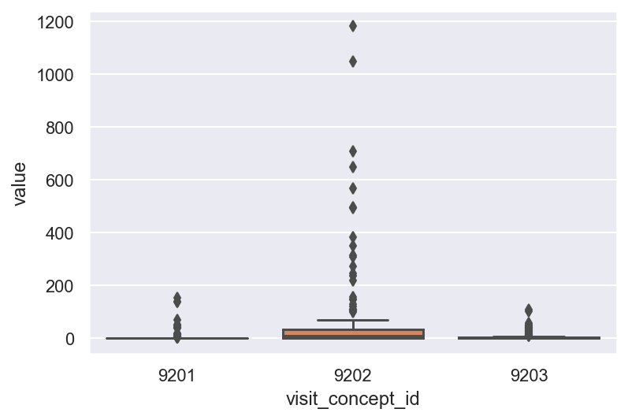

```python
sns.boxplot(x="visit_concept_id", y="value", data=pd.melt(vo_count2))

plt.show()
```

```python
vo_count2.describe()
```

| visit_concept_id | 9201 | 9202 | 9203 |
| --- | --- | --- | --- |
| count | 151.000000 | 151.000000 | 151.000000 |
| mean | 5.980132 | 67.562914 | 7.033113 |
| std | 22.300514 | 172.313651 | 16.874603 |
| min | 0.000000 | 0.000000 | 0.000000 |
| 25% | 0.000000 | 0.000000 | 0.000000 |
| 50% | 0.000000 | 7.000000 | 0.000000 |
| 75% | 0.000000 | 32.500000 | 3.000000 |
| max | 153.000000 | 1182.000000 | 106.000000 |

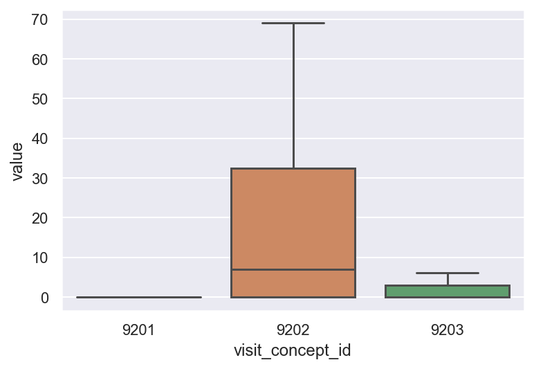

```python
sns.boxplot(x="visit_concept_id", y="value", data=pd.melt(vo_count2), showfliers=False)

plt.show()
```

# 백인 EDA

```python
white_profile = profile2[profile2.race_source_value == 'white']
```

```python
white_profile
```

|  | person_id | birth_datetime | race_source_value | ethnicity_source_value | male | cause_source_value | death | age | death_date |
| --- | --- | --- | --- | --- | --- | --- | --- | --- | --- |
| 0 | 402435 | 1997-04-18 | white | hispanic | 0 | NaN | 0 | 23 | NaT |
| 1 | 1022983 | 1950-02-26 | white | hispanic | 1 | NaN | 0 | 70 | NaT |
| 2 | 1657794 | 1937-12-10 | white | hispanic | 0 | NaN | 0 | 83 | NaT |
| 4 | 2693038 | 1959-02-07 | white | nonhispanic | 0 | NaN | 0 | 62 | NaT |
| 5 | 2297327 | 1948-04-07 | white | nonhispanic | 1 | NaN | 0 | 72 | NaT |
| ... | ... | ... | ... | ... | ... | ... | ... | ... | ... |
| 995 | 275512 | 1921-06-25 | white | nonhispanic | 1 | 126906006.0 | 1 | 65 | 1986-09-02 |
| 996 | 1743075 | 1937-12-05 | white | nonhispanic | 1 | 840539006.0 | 1 | 82 | 2020-03-04 |
| 997 | 81025 | 1930-01-29 | white | nonhispanic | 1 | 840539006.0 | 1 | 90 | 2020-03-26 |
| 998 | 1635233 | 1981-05-13 | white | nonhispanic | 1 | 95281009.0 | 1 | 32 | 2013-08-03 |
| 999 | 1059760 | 1947-07-07 | white | nonhispanic | 0 | 840539006.0 | 1 | 72 | 2020-03-20 |

845 rows × 9 columns

## 분포

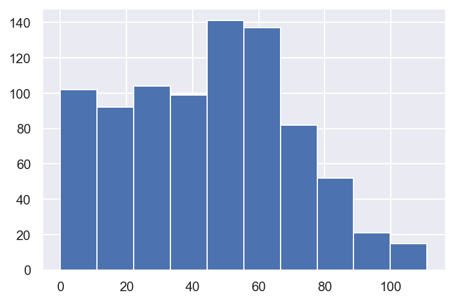

```python
plt.hist('age', data=white_profile)
```

```python
from sklearn.model_selection import train_test_split
from sklearn.linear_model import LogisticRegression
from sklearn.metrics import accuracy_score
import statsmodels.api as sm
```

```python
white_profile = pd.concat([white_profile,pd.get_dummies(white_profile.ethnicity_source_value)], axis=1)
```

```python
white_profile['hispanic'] = white_profile.hispanic.apply(lambda x: int(x))
```

```python
white_profile['male'] = white_profile.male.apply(lambda x: int(x))
```

```python
white_profile.columns
```

```
Index(['person_id', 'birth_datetime', 'race_source_value',
       'ethnicity_source_value', 'male', 'cause_source_value', 'death', 'age',
       'death_date', 'hispanic', 'nonhispanic', 'condition_count', 'age_range',
       'mean_visit_days'],
      dtype='object')
```

```python
white_profile.info()
```

[output not shown]

```python
white_profile['condition_count'] = 0
```

```python
white_profile.condition_count.value_counts()
```

```
0    845
Name: condition_count, dtype: int64
```

```python
# 상병 보유 갯수
for each in white_profile.person_id.values:
    if each in cvo.person_id.unique():
        count = len(cvo[cvo.person_id==each].condition_concept_id.unique())
        white_profile.condition_count.loc[white_profile.person_id==each] = count
white_profile.condition_count.unique()
```

```
array([10, 21, 11,  6, 16, 17, 12,  3,  9,  8,  7,  5, 15, 13,  0, 18,  4,
       14, 19, 22,  2,  1, 23, 25, 20, 24, 27, 33, 28, 30])
```

```python
white_profile['mean_visit_days'] = 0
```

```python
cvo['mean_visit_days'] = 0
```

```python
cvo.head()
```

|  | person_id | condition_occurrence_id | condition_concept_id | condition_start_date | condition_end_date | visit_occurrence_id | condition_source_value | visit_concept_id | visit_start_date | visit_end_date | preceding_visit_occurrence_id | mean_visit_days |
| --- | --- | --- | --- | --- | --- | --- | --- | --- | --- | --- | --- | --- |
| 0 | 116496 | 1466183 | 0 | 2002-11-29 | NaN | 36112954 | 162864005 | 9202 | 2002-11-29 | 2002-11-29 | 36112944.0 | 0 |
| 1 | 116496 | 1466184 | 0 | 2020-03-04 | 2020-03-04 | 36112952 | 840544004 | 9202 | 2020-03-04 | 2020-03-04 | 36112964.0 | 0 |
| 2 | 116496 | 1466187 | 312437 | 2020-03-04 | 2020-04-04 | 36112952 | 267036007 | 9202 | 2020-03-04 | 2020-03-04 | 36112964.0 | 0 |
| 3 | 116496 | 1466188 | 314754 | 2020-03-04 | 2020-04-04 | 36112952 | 56018004 | 9202 | 2020-03-04 | 2020-03-04 | 36112964.0 | 0 |
| 4 | 116496 | 1466190 | 4223659 | 2020-03-04 | 2020-04-04 | 36112952 | 84229001 | 9202 | 2020-03-04 | 2020-03-04 | 36112964.0 | 0 |

```python
cvo['visit_start_date'] = cvo['visit_start_date'].apply(lambda x: datetime.datetime.strptime(x, '%Y-%m-%d'))
```

```python
cvo['visit_end_date'] = cvo['visit_end_date'].apply(lambda x: datetime.datetime.strptime(x, '%Y-%m-%d'))
```

```python
cvo['mean_visit_days'] = cvo.apply(lambda x: x.visit_end_date - x.visit_start_date, axis=1)
```

```python
cvo['mean_visit_days'] = cvo['mean_visit_days'].apply(lambda x: x.days)
```

```python
mean_visit_days = pd.DataFrame(round(cvo.groupby('person_id')['mean_visit_days'].mean()))
```

```python
mean_visit_days.reset_index(inplace=True)
mean_visit_days
```

|  | person_id | mean_visit_days |
| --- | --- | --- |
| 0 | 2955 | 0.0 |
| 1 | 4915 | 0.0 |
| 2 | 11992 | 0.0 |
| 3 | 12111 | 0.0 |
| 4 | 13328 | 0.0 |
| ... | ... | ... |
| 988 | 2837387 | 0.0 |
| 989 | 2840192 | 3.0 |
| 990 | 2840336 | 0.0 |
| 991 | 2843890 | 2.0 |
| 992 | 2845932 | 0.0 |

993 rows × 2 columns

```python
int(mean_visit_days[mean_visit_days.person_id==2955]['mean_visit_days'])
```

```
0
```

```python
for each in white_profile.person_id.values:
    if each in mean_visit_days.person_id.values:
        days = int(mean_visit_days[mean_visit_days.person_id==each]['mean_visit_days'])
        white_profile.mean_visit_days.loc[white_profile.person_id==each]= days
white_profile.mean_visit_days.unique()
```

```
array([  0,   2,   1,   7,   4,   3,   8,   5,   6, 233,   9,  35])
```

```python
white_profile.mean_visit_days.value_counts()
```

```
0      688
2       50
1       43
3       31
4       15
5        9
7        4
233      1
35       1
9        1
8        1
6        1
Name: mean_visit_days, dtype: int64
```

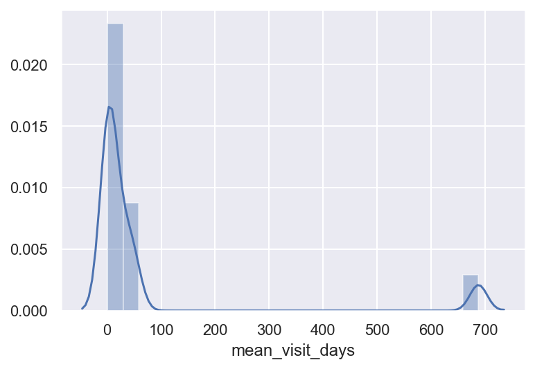

```python
sns.distplot(white_profile.mean_visit_days.value_counts())
```

```python
X
```

|  | male | age | hispanic | condition_count | age_range | mean_visit_days |
| --- | --- | --- | --- | --- | --- | --- |
| 0 | 0 | 23 | 1 | 10 | 0 | 0 |
| 1 | 1 | 70 | 1 | 21 | 0 | 2 |
| 2 | 0 | 83 | 1 | 11 | 0 | 0 |
| 4 | 0 | 62 | 0 | 6 | 0 | 0 |
| 5 | 1 | 72 | 0 | 11 | 0 | 0 |
| ... | ... | ... | ... | ... | ... | ... |
| 995 | 1 | 65 | 0 | 6 | 0 | 0 |
| 996 | 1 | 82 | 0 | 30 | 0 | 2 |
| 997 | 1 | 90 | 0 | 23 | 0 | 5 |
| 998 | 1 | 32 | 0 | 6 | 0 | 0 |
| 999 | 0 | 72 | 0 | 21 | 0 | 35 |

845 rows × 6 columns

```python
X = white_profile.drop(['person_id', 'birth_datetime', 'ethnicity_source_value', 'race_source_value', 'cause_source_value', 'death', 'death_date', 'nonhispanic', 'age_range'], axis=1)
y = white_profile['death']
```

```python
train = pd.concat([X,y], axis=1)
```

```python
train
```

|  | male | age | hispanic | condition_count | mean_visit_days | death |
| --- | --- | --- | --- | --- | --- | --- |
| 0 | 0 | 23 | 1 | 10 | 0 | 0 |
| 1 | 1 | 70 | 1 | 21 | 2 | 0 |
| 2 | 0 | 83 | 1 | 11 | 0 | 0 |
| 4 | 0 | 62 | 0 | 6 | 0 | 0 |
| 5 | 1 | 72 | 0 | 11 | 0 | 0 |
| ... | ... | ... | ... | ... | ... | ... |
| 995 | 1 | 65 | 0 | 6 | 0 | 1 |
| 996 | 1 | 82 | 0 | 30 | 2 | 1 |
| 997 | 1 | 90 | 0 | 23 | 5 | 1 |
| 998 | 1 | 32 | 0 | 6 | 0 | 1 |
| 999 | 0 | 72 | 0 | 21 | 35 | 1 |

845 rows × 6 columns

```python
formula = 'y ~ male + age + hispanic + condition_count + mean_visit_days'
lor = sm.Logit.from_formula(formula, train).fit()
```

```
Optimization terminated successfully.
         Current function value: 0.395306
         Iterations 6
```

```python
print(lor.summary())
```

```
                           Logit Regression Results
==============================================================================
Dep. Variable:                      y   No. Observations:                  845
Model:                          Logit   Df Residuals:                      839
Method:                           MLE   Df Model:                            5
Date:                Sun, 07 Feb 2021   Pseudo R-squ.:                 0.07045
Time:                        23:51:03   Log-Likelihood:                -334.03
converged:                       True   LL-Null:                       -359.35
Covariance Type:            nonrobust   LLR p-value:                 1.028e-09
===================================================================================
                      coef    std err          z      P>|z|      [0.025      0.975]
-----------------------------------------------------------------------------------
Intercept          -3.4034      0.344     -9.906      0.000      -4.077      -2.730
male                0.5944      0.208      2.863      0.004       0.187       1.001
age                 0.0250      0.004      5.938      0.000       0.017       0.033
hispanic            0.1884      0.295      0.638      0.523      -0.390       0.767
condition_count     0.0040      0.020      0.199      0.843      -0.036       0.044
mean_visit_days    -0.0017      0.012     -0.147      0.883      -0.025       0.021
===================================================================================
```

```python
lor.pvalues
```

```
Intercept          3.934202e-23
male               4.201506e-03
age                2.891914e-09
hispanic           5.233235e-01
condition_count    8.425194e-01
mean_visit_days    8.832046e-01
dtype: float64
```

```python
lor.params
```

```
Intercept         -3.403422
male               0.594448
age                0.024958
hispanic           0.188367
condition_count    0.004043
mean_visit_days   -0.001724
dtype: float64
```

# 기타

```python
# 입원 경험밖에 없다면
```

```python
vo_count = pd.crosstab(cvo.condition_concept_id, cvo.visit_concept_id, margins=True)
vo_count2 = pd.crosstab(cvo.condition_concept_id, cvo.visit_concept_id)
```

```python
i1 = cvo.set_index(cvo.person_id.values).index
i2 = white_profile.set_index(white_profile.person_id.values).index
```

```python
len(i1), len(i2)
```

```
(12167, 845)
```

```python
death
```

|  | person_id | death_date | cause_source_value |
| --- | --- | --- | --- |
| 0 | 1691806 | 2015-06-02 | 233604007 |
| 1 | 99181 | 2018-11-04 | 87433001 |
| 2 | 2738610 | 1998-03-28 | 262574004 |
| 3 | 31196 | 2020-03-16 | 840539006 |
| 4 | 994339 | 2006-03-08 | 22298006 |
| ... | ... | ... | ... |
| 147 | 359466 | 1937-10-22 | 95281009 |
| 148 | 1891866 | 1998-10-11 | 126906006 |
| 149 | 533445 | 2003-08-06 | 22298006 |
| 150 | 2399178 | 2020-02-05 | 22298006 |
| 151 | 631283 | 2017-11-16 | 230690007 |

152 rows × 3 columns

```python
cvo[list(i1.isin(i2))]
```

|  | person_id | condition_occurrence_id | condition_concept_id | condition_start_date | condition_end_date | visit_occurrence_id | condition_source_value | visit_concept_id | visit_start_date | visit_end_date | preceding_visit_occurrence_id |
| --- | --- | --- | --- | --- | --- | --- | --- | --- | --- | --- | --- |
| 0 | 116496 | 1466183 | 0 | 2002-11-29 | NaN | 36112954 | 162864005 | 9202 | 2002-11-29 | 2002-11-29 | 36112944.0 |
| 1 | 116496 | 1466184 | 0 | 2020-03-04 | 2020-03-04 | 36112952 | 840544004 | 9202 | 2020-03-04 | 2020-03-04 | 36112964.0 |
| 2 | 116496 | 1466187 | 312437 | 2020-03-04 | 2020-04-04 | 36112952 | 267036007 | 9202 | 2020-03-04 | 2020-03-04 | 36112964.0 |
| 3 | 116496 | 1466188 | 314754 | 2020-03-04 | 2020-04-04 | 36112952 | 56018004 | 9202 | 2020-03-04 | 2020-03-04 | 36112964.0 |
| 4 | 116496 | 1466190 | 4223659 | 2020-03-04 | 2020-04-04 | 36112952 | 84229001 | 9202 | 2020-03-04 | 2020-03-04 | 36112964.0 |
| ... | ... | ... | ... | ... | ... | ... | ... | ... | ... | ... | ... |
| 12130 | 595435 | 7501784 | 4311629 | 2011-01-01 | NaN | 89059491 | 15777000 | 9202 | 2010-12-31 | 2010-12-31 | 89059474.0 |
| 12131 | 595435 | 7501778 | 4112343 | 2011-10-27 | 2011-11-03 | 89059455 | 195662009 | 9202 | 2011-10-26 | 2011-10-26 | 89059476.0 |
| 12132 | 595435 | 7501779 | 4112343 | 2012-11-01 | 2012-11-08 | 89059456 | 195662009 | 9202 | 2012-10-31 | 2012-10-31 | 89059477.0 |
| 12133 | 595435 | 7501780 | 4146173 | 2015-07-25 | 2015-08-24 | 89059469 | 307731004 | 9202 | 2015-07-24 | 2015-07-24 | 89059481.0 |
| 12134 | 595435 | 7501781 | 4217975 | 2013-07-20 | 2014-03-08 | 89059457 | 72892002 | 9202 | 2013-07-19 | 2013-07-20 | 89059478.0 |

10191 rows × 11 columns

```python
co
```

|  | person_id | condition_occurrence_id | condition_concept_id | condition_start_date | condition_end_date | visit_occurrence_id | condition_source_value |
| --- | --- | --- | --- | --- | --- | --- | --- |
| 0 | 116496 | 1466183 | 0 | 2002-11-29 | NaN | 36112954 | 162864005 |
| 1 | 116496 | 1466184 | 0 | 2020-03-04 | 2020-03-04 | 36112952 | 840544004 |
| 2 | 116496 | 1466185 | 81151 | 2015-03-24 | 2015-04-14 | 7021052 | 44465007 |
| 3 | 116496 | 1466186 | 260139 | 2012-10-23 | 2012-10-30 | 36112948 | 10509002 |
| 4 | 116496 | 1466187 | 312437 | 2020-03-04 | 2020-04-04 | 36112952 | 267036007 |
| ... | ... | ... | ... | ... | ... | ... | ... |
| 12162 | 2781995 | 35049923 | 4112343 | 2010-07-08 | 2010-07-19 | 48895518 | 195662009 |
| 12163 | 2781995 | 35049924 | 4112343 | 2012-10-08 | 2012-10-19 | 48895519 | 195662009 |
| 12164 | 2781995 | 35049925 | 4147326 | 2020-03-09 | 2020-04-05 | 48895521 | 267102003 |
| 12165 | 2781995 | 35049926 | 37311061 | 2020-03-09 | 2020-04-05 | 48895521 | 840539006 |
| 12166 | 2781995 | 35049927 | 40481087 | 2019-08-31 | 2019-09-21 | 48895520 | 444814009 |

12167 rows × 7 columns

```python
# 이 사람들은 병원에 왜 방문했을까?
- 방문유형과 성별로 scatterplot
- 진단병명과 성별로 scatterplot
```

```python
df_new = df.drop_duplicates(['JID', 'MSICK_CD2'], keep='first')
```

```python
v_concept = vo.drop_duplicates(['person_id', 'visit_concept_id'], keep='first')
v_concept.head()
```

|  | visit_occurrence_id | person_id | visit_concept_id | visit_start_date | visit_end_date | preceding_visit_occurrence_id |
| --- | --- | --- | --- | --- | --- | --- |
| 0 | 36112943 | 116496 | 9202 | 1962-04-13 | 1962-04-13 | NaN |
| 13 | 7021052 | 116496 | 9203 | 2015-03-24 | 2015-03-24 | 36112959.0 |
| 22 | 31254229 | 886110 | 9202 | 1957-08-24 | 1957-08-24 | NaN |
| 27 | 6522212 | 886110 | 9203 | 2014-08-14 | 2014-08-14 | 31254233.0 |
| 31 | 3824839 | 886110 | 9201 | 2017-08-10 | 2017-08-11 | 31254236.0 |

```python
temp = pd.get_dummies(v_concept[['person_id', 'visit_concept_id']].set_index('person_id'), 'visit_concept_id')
```

```python
temp = pd.get_dummies(temp['visit_concept_id'])
```

```python
temp.reset_index(inplace=True)
```

```python
white_profile.head()
```

|  | person_id | birth_datetime | race_source_value | ethnicity_source_value | male | cause_source_value | death | age | death_date |
| --- | --- | --- | --- | --- | --- | --- | --- | --- | --- |
| 0 | 402435 | 1997-04-18 | white | hispanic | 0 | NaN | 0 | 23 | NaT |
| 1 | 1022983 | 1950-02-26 | white | hispanic | 1 | NaN | 0 | 70 | NaT |
| 2 | 1657794 | 1937-12-10 | white | hispanic | 0 | NaN | 0 | 83 | NaT |
| 4 | 2693038 | 1959-02-07 | white | nonhispanic | 0 | NaN | 0 | 62 | NaT |
| 5 | 2297327 | 1948-04-07 | white | nonhispanic | 1 | NaN | 0 | 72 | NaT |

```python
temp = pd.merge(v_concept, white_profile, on='person_id')
temp
```

|  | visit_occurrence_id | person_id | visit_concept_id | visit_start_date | visit_end_date | preceding_visit_occurrence_id | birth_datetime | race_source_value | ethnicity_source_value | male | cause_source_value | death | age | death_date |
| --- | --- | --- | --- | --- | --- | --- | --- | --- | --- | --- | --- | --- | --- | --- |
| 0 | 36112943 | 116496 | 9202 | 1962-04-13 | 1962-04-13 | NaN | 1960-11-18 | white | nonhispanic | 1 | NaN | 0 | 60 | NaT |
| 1 | 7021052 | 116496 | 9203 | 2015-03-24 | 2015-03-24 | 36112959.0 | 1960-11-18 | white | nonhispanic | 1 | NaN | 0 | 60 | NaT |
| 2 | 31254229 | 886110 | 9202 | 1957-08-24 | 1957-08-24 | NaN | 1949-08-27 | white | nonhispanic | 1 | NaN | 0 | 71 | NaT |
| 3 | 6522212 | 886110 | 9203 | 2014-08-14 | 2014-08-14 | 31254233.0 | 1949-08-27 | white | nonhispanic | 1 | NaN | 0 | 71 | NaT |
| 4 | 3824839 | 886110 | 9201 | 2017-08-10 | 2017-08-11 | 31254236.0 | 1949-08-27 | white | nonhispanic | 1 | NaN | 0 | 71 | NaT |
| ... | ... | ... | ... | ... | ... | ... | ... | ... | ... | ... | ... | ... | ... | ... |
| 1781 | 16403195 | 2119555 | 9203 | 2018-02-10 | 2018-02-10 | 126975969.0 | 1985-02-12 | white | nonhispanic | 0 | NaN | 0 | 35 | NaT |
| 1782 | 1221030 | 2119555 | 9201 | 2018-02-17 | 2018-02-18 | 16403195.0 | 1985-02-12 | white | nonhispanic | 0 | NaN | 0 | 35 | NaT |
| 1783 | 29192532 | 2296477 | 9202 | 2011-01-17 | 2011-01-17 | NaN | 1993-11-29 | white | nonhispanic | 0 | NaN | 0 | 27 | NaT |
| 1784 | 89059489 | 595435 | 9202 | 1985-10-18 | 1985-10-18 | NaN | 1976-10-16 | white | nonhispanic | 0 | NaN | 0 | 44 | NaT |
| 1785 | 12484146 | 595435 | 9203 | 2014-03-07 | 2014-03-08 | 89059467.0 | 1976-10-16 | white | nonhispanic | 0 | NaN | 0 | 44 | NaT |

1786 rows × 14 columns

```python
visit_concept_id
```

|  | 9201 | 9202 | 9203 | age | birth_datetime | cause_source_value | death | death_date | ethnicity_source_value | male | person_id | preceding_visit_occurrence_id | race_source_value | visit_concept_id | visit_end_date | visit_occurrence_id | visit_start_date |
| --- | --- | --- | --- | --- | --- | --- | --- | --- | --- | --- | --- | --- | --- | --- | --- | --- | --- |
| 0 | NaN | NaN | NaN | 60.0 | 1960-11-18 | NaN | 0.0 | NaT | nonhispanic | 1.0 | 116496.0 | NaN | white | 9202.0 | 1962-04-13 | 36112943.0 | 1962-04-13 |
| 1 | NaN | NaN | NaN | 60.0 | 1960-11-18 | NaN | 0.0 | NaT | nonhispanic | 1.0 | 116496.0 | 36112959.0 | white | 9203.0 | 2015-03-24 | 7021052.0 | 2015-03-24 |
| 2 | NaN | NaN | NaN | 71.0 | 1949-08-27 | NaN | 0.0 | NaT | nonhispanic | 1.0 | 886110.0 | NaN | white | 9202.0 | 1957-08-24 | 31254229.0 | 1957-08-24 |
| 3 | NaN | NaN | NaN | 71.0 | 1949-08-27 | NaN | 0.0 | NaT | nonhispanic | 1.0 | 886110.0 | 31254233.0 | white | 9203.0 | 2014-08-14 | 6522212.0 | 2014-08-14 |
| 4 | NaN | NaN | NaN | 71.0 | 1949-08-27 | NaN | 0.0 | NaT | nonhispanic | 1.0 | 886110.0 | 31254236.0 | white | 9201.0 | 2017-08-11 | 3824839.0 | 2017-08-10 |
| ... | ... | ... | ... | ... | ... | ... | ... | ... | ... | ... | ... | ... | ... | ... | ... | ... | ... |
| 1781 | 0.0 | 0.0 | 1.0 | NaN | NaN | NaN | NaN | NaT | NaN | NaN | NaN | NaN | NaN | NaN | NaN | NaN | NaN |
| 1782 | 1.0 | 0.0 | 0.0 | NaN | NaN | NaN | NaN | NaT | NaN | NaN | NaN | NaN | NaN | NaN | NaN | NaN | NaN |
| 1783 | 0.0 | 1.0 | 0.0 | NaN | NaN | NaN | NaN | NaT | NaN | NaN | NaN | NaN | NaN | NaN | NaN | NaN | NaN |
| 1784 | 0.0 | 1.0 | 0.0 | NaN | NaN | NaN | NaN | NaT | NaN | NaN | NaN | NaN | NaN | NaN | NaN | NaN | NaN |
| 1785 | 0.0 | 0.0 | 1.0 | NaN | NaN | NaN | NaN | NaT | NaN | NaN | NaN | NaN | NaN | NaN | NaN | NaN | NaN |

3572 rows × 17 columns

```python
white_profile
```

|  | person_id | birth_datetime | race_source_value | ethnicity_source_value | male | cause_source_value | death | age | death_date |
| --- | --- | --- | --- | --- | --- | --- | --- | --- | --- |
| 0 | 402435 | 1997-04-18 | white | hispanic | 0 | NaN | 0 | 23 | NaT |
| 1 | 1022983 | 1950-02-26 | white | hispanic | 1 | NaN | 0 | 70 | NaT |
| 2 | 1657794 | 1937-12-10 | white | hispanic | 0 | NaN | 0 | 83 | NaT |
| 4 | 2693038 | 1959-02-07 | white | nonhispanic | 0 | NaN | 0 | 62 | NaT |
| 5 | 2297327 | 1948-04-07 | white | nonhispanic | 1 | NaN | 0 | 72 | NaT |
| ... | ... | ... | ... | ... | ... | ... | ... | ... | ... |
| 995 | 275512 | 1921-06-25 | white | nonhispanic | 1 | 126906006.0 | 1 | 65 | 1986-09-02 |
| 996 | 1743075 | 1937-12-05 | white | nonhispanic | 1 | 840539006.0 | 1 | 82 | 2020-03-04 |
| 997 | 81025 | 1930-01-29 | white | nonhispanic | 1 | 840539006.0 | 1 | 90 | 2020-03-26 |
| 998 | 1635233 | 1981-05-13 | white | nonhispanic | 1 | 95281009.0 | 1 | 32 | 2013-08-03 |
| 999 | 1059760 | 1947-07-07 | white | nonhispanic | 0 | 840539006.0 | 1 | 72 | 2020-03-20 |

845 rows × 9 columns

```python
temp2 = pd.concat([profile2, temp], join='outer', keys='person_id')
```

```python
temp2
```

|  |  | person_id | birth_datetime | race_source_value | ethnicity_source_value | male | cause_source_value | death | age | death_date | 9201 | 9202 | 9203 |
| --- | --- | --- | --- | --- | --- | --- | --- | --- | --- | --- | --- | --- | --- |
| p | 0 | 402435 | 1997-04-18 | white | hispanic | 0.0 | NaN | 0.0 | 23.0 | NaT | NaN | NaN | NaN |
|  | 1 | 1022983 | 1950-02-26 | white | hispanic | 1.0 | NaN | 0.0 | 70.0 | NaT | NaN | NaN | NaN |
|  | 2 | 1657794 | 1937-12-10 | white | hispanic | 0.0 | NaN | 0.0 | 83.0 | NaT | NaN | NaN | NaN |
|  | 3 | 2845932 | 1987-05-26 | asian | hispanic | 1.0 | NaN | 0.0 | 33.0 | NaT | NaN | NaN | NaN |
|  | 4 | 2693038 | 1959-02-07 | white | nonhispanic | 0.0 | NaN | 0.0 | 62.0 | NaT | NaN | NaN | NaN |
| ... | ... | ... | ... | ... | ... | ... | ... | ... | ... | ... | ... | ... | ... |
| e | 2107 | 595435 | NaN | NaN | NaN | NaN | NaN | NaN | NaN | NaT | 0.0 | 0.0 | 1.0 |
|  | 2108 | 631283 | NaN | NaN | NaN | NaN | NaN | NaN | NaN | NaT | 0.0 | 1.0 | 0.0 |
|  | 2109 | 631283 | NaN | NaN | NaN | NaN | NaN | NaN | NaN | NaT | 0.0 | 0.0 | 1.0 |
|  | 2110 | 2781995 | NaN | NaN | NaN | NaN | NaN | NaN | NaN | NaT | 0.0 | 1.0 | 0.0 |
|  | 2111 | 2781995 | NaN | NaN | NaN | NaN | NaN | NaN | NaN | NaT | 0.0 | 0.0 | 1.0 |

3112 rows × 12 columns

```python
pd.crosstab()
```

[output not shown]

```python
pd.merge(profile2, temp, left_index=True)
```

[output not shown]

```python
visit_concept_id_ls = []
for i in v_concept.person_id.unique():
    id = v_concept[v_concept.person_id == i]['visit_concept_id'].unique()
    visit_concept_id_ls.append({i:list(id)})
```

```python
df = pd.DataFrame(visit_concept_id_ls)
```

- 입원: visit_concept_id=9201
- 외래: visit_concept_id=9202
- 응급: visit_concept_id=9203

```python
vo.visit_occurrence_id.nunique()
```

```
41810
```

```python
vo
```

|  | visit_occurrence_id | person_id | visit_concept_id | visit_start_date | visit_end_date | preceding_visit_occurrence_id |
| --- | --- | --- | --- | --- | --- | --- |
| 0 | 36112943 | 116496 | 9202 | 1962-04-13 | 1962-04-13 | NaN |
| 1 | 36112944 | 116496 | 9202 | 1962-04-24 | 1962-04-24 | 36112943.0 |
| 2 | 36112954 | 116496 | 9202 | 2002-11-29 | 2002-11-29 | 36112944.0 |
| 3 | 36112945 | 116496 | 9202 | 2008-11-06 | 2008-11-06 | 36112954.0 |
| 4 | 36112946 | 116496 | 9202 | 2010-11-19 | 2010-11-19 | 36112945.0 |
| ... | ... | ... | ... | ... | ... | ... |
| 41805 | 48895529 | 2781995 | 9202 | 2018-02-14 | 2018-02-14 | 48895528.0 |
| 41806 | 48895530 | 2781995 | 9202 | 2019-02-20 | 2019-02-20 | 48895529.0 |
| 41807 | 48895520 | 2781995 | 9202 | 2019-08-30 | 2019-08-30 | 48895530.0 |
| 41808 | 48895531 | 2781995 | 9202 | 2020-02-26 | 2020-02-26 | 48895520.0 |
| 41809 | 48895521 | 2781995 | 9202 | 2020-03-08 | 2020-03-08 | 48895531.0 |

41810 rows × 6 columns